# Lecture 7: Exercises with Answers

October 18th, 2018

`r`r library(tidyverse)

# Exercise 1: Hypothesis testing

Similarly to dataset `mtcars`, the dataset `mpg` from `ggplot` package includes data on automobiles. However, `mpg` includes data for newer cars from year 1999 and 2008. The variables measured for each car is slighly different. Here we are interested in the variable, `hwy`, the highway miles per gallon.

```r
# We first format the column trans to contain only info on transmission auto/manual
mpg
```

```
# A tibble: 234 x 11
   manufacturer model      displ  year   cyl trans      drv     cty   hwy fl    class
   <chr>        <chr>      <dbl> <int> <int> <chr>      <chr> <int> <int> <chr> <chr>
 1 audi         a4           1.8  1999     4 auto(l5)   f        18    29 p     compact
 2 audi         a4           1.8  1999     4 manual(m5) f        21    29 p     compact
 3 audi         a4           2    2008     4 manual(m6) f        20    31 p     compact
 4 audi         a4           2    2008     4 auto(av)   f        21    30 p     compact
 5 audi         a4           2.8  1999     6 auto(l5)   f        16    26 p     compact
 6 audi         a4           2.8  1999     6 manual(m5) f        18    26 p     compact
 7 audi         a4           3.1  2008     6 auto(av)   f        18    27 p     compact
 8 audi         a4 quattro   1.8  1999     4 manual(m5) 4        18    26 p     compact
 9 audi         a4 quattro   1.8  1999     4 auto(l5)   4        16    25 p     compact
10 audi         a4 quattro   2    2008     4 manual(m6) 4        20    28 p     compact
# ... with 224 more rows
```

```r
mpg <- mpg %>%
  mutate(
    trans = strsplit(trans, "\\(")[[1]][1],
    trans = factor(trans, levels = c("auto", "manual"))
  )
mpg
```

[output not shown]

## Part 2: One-sample test

1. Subset the `mpg` dataset to inlude only cars from year 2008.

`r`r mpg2008 <- mpg %>% filter(year == 2008)

2. Test whether cars from 2008 have mean the highway miles per gallon, `hwy`, equal to 30 mpg.

`r`r t.test(mpg2008$hwy, mu = 30, alternative = .sided)

```
    One Sample t-test

data:  mpg2008$hwy
t = -12.11, df = 116, p-value < 2.2e-16
alternative hypothesis: true mean is not equal to 30
95 percent confidence interval:
 22.38218 24.52380
sample estimates:
mean of x
 23.45299
```

3. Test whether cars from 2008 with 4 cylinders have mean `hwy` equal to 30 mpg.

`r`r mpg2008_4cyl <- mpg %>% filter(year == 2008, cyl == 4) t.test(mpg2008_4cyl$hwy, mu = 30, alternative = .sided)

```
    One Sample t-test

data:  mpg2008_4cyl$hwy
t = -1.1492, df = 35, p-value = 0.2582
alternative hypothesis: true mean is not equal to 30
95 percent confidence interval:
 28.15568 30.51098
sample estimates:
mean of x
 29.33333
```

## Part 2: Two-sample test

1. Test if the mean `hwy` for automatic is **less than** that for manual cars **in 2008**. Generate a boxplot with jittered points for `hwy` for each transmission group.

`r`r t.test(data = mpg2008, hwy ~ transmission, alternative = )

```
    Welch Two Sample t-test

data:  hwy by transmission
t = -3.1269, df = 64.928, p-value = 0.001322
alternative hypothesis: true difference in means is less than 0
95 percent confidence interval:
      -Inf -1.635703
sample estimates:
  mean in group auto mean in group manual
            22.43373             25.94118
```

`r`r # or # t.test(x = mpg2008 %>% filter(transmission == ) %>% pull(hwy), # y = mpg2008 %>% filter(transmission == ) %>% pull(hwy), # alternative = )

`r`r ggplot(mpg2008, aes(x = transmission, y = hwy)) + geom_boxplot() + geom_jitter(height = 0, width = 0.2)

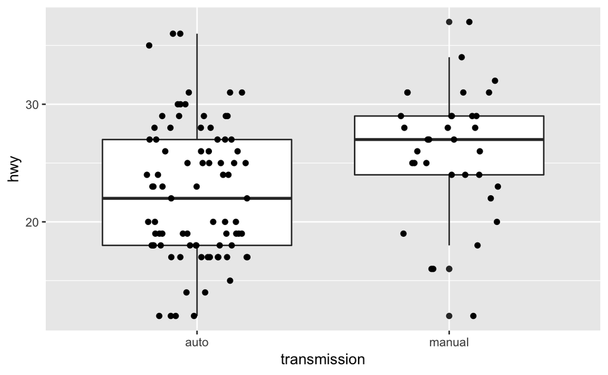

2. Test if the mean `hwy` for cars from 1999 and is greater than that for cars from 2008. Generate a boxplot with jittered points for `hwy` for each year group.

`r`r t.test(data = mpg, hwy ~ year, alternative = )

```
    Welch Two Sample t-test

data:  hwy by year
t = -0.032864, df = 231.64, p-value = 0.5131
alternative hypothesis: true difference in means is greater than 0
95 percent confidence interval:
 -1.314123       Inf
sample estimates:
mean in group 1999 mean in group 2008
          23.42735           23.45299
```

`r`r ggplot(mpg, aes(x = factor(year), y = hwy)) + geom_boxplot() + geom_jitter(height = 0, width = 0.2)

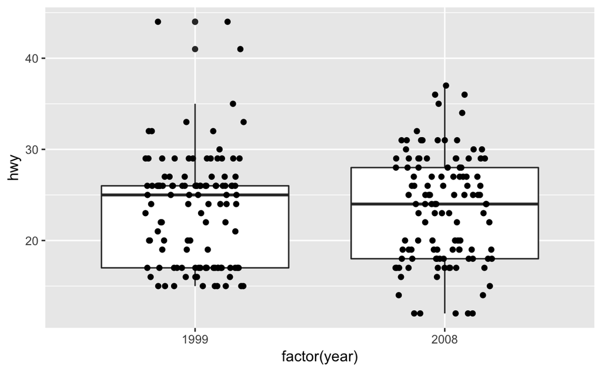

# Exercise 2: Logistic Regression

In this you will use a dataset `Default`, on customer default records for a credit card company, which is included in ISL book. To obtain the data you will need to install a package `ISLR`.

`r`r # install.packages() library(ISLR) (Default <- tbl_df(Default))

```
# A tibble: 10,000 x 4
   default student balance income
   <fct>   <fct>     <dbl>  <dbl>
 1 No      No         730. 44362.
 2 No      Yes        817. 12106.
 3 No      No        1074. 31767.
 4 No      No         529. 35704.
 5 No      No         786. 38463.
 6 No      Yes        920.  7492.
 7 No      No         826. 24905.
 8 No      Yes        809. 17600.
 9 No      No        1161. 37469.
10 No      No           0  29275.
# ... with 9,990 more rows
```

1. First, divide your dataset into a train and test set. Randomly sample 6000 observations and include them in the train set, and the remaining use as a test set.

`r`r train.idx <- sample(1:nrow(Default), 6000, replace = FALSE) train <- Default[train.idx, ] test <- Default[-train.idx, ]

2. Fit a logistic regression including all the features to predict whether a customer defaulted or not.

`r`r fit.logit <- glm(default ~ student + balance + income, data = train, family = ) summary(fit.logit)

```
Call:
glm(formula = default ~ student + balance + income, family = \binomial\,
    data = train)

Deviance Residuals:
    Min       1Q   Median       3Q      Max
-2.3942  -0.1484  -0.0608  -0.0233   3.6901

Coefficients:
              Estimate Std. Error z value Pr(>|z|)
(Intercept) -1.083e+01  6.345e-01 -17.074   <2e-16 ***
studentYes  -2.834e-01  3.041e-01  -0.932    0.351
balance      5.508e-03  2.895e-04  19.022   <2e-16 ***
income       9.381e-06  1.057e-05   0.887    0.375
---
Signif. codes:  0 ‘***’ 0.001 ‘**’ 0.01 ‘*’ 0.05 ‘.’ 0.1 ‘ ’ 1

(Dispersion parameter for binomial family taken to be 1)

    Null deviance: 1733.49  on 5999  degrees of freedom
Residual deviance:  961.94  on 5996  degrees of freedom
AIC: 969.94

Number of Fisher Scoring iterations: 8
```

3. Note if any variables seem not significant. Then, adjust your model accordingly (by removing them).

`r`r fit.logit <- glm(default ~ student + balance, data = train, family = ) summary(fit.logit)

```
Call:
glm(formula = default ~ student + balance, family = \binomial\,
    data = train)

Deviance Residuals:
    Min       1Q   Median       3Q      Max
-2.3569  -0.1480  -0.0607  -0.0234   3.7045

Coefficients:
              Estimate Std. Error z value Pr(>|z|)
(Intercept) -1.045e+01  4.597e-01 -22.740  < 2e-16 ***
studentYes  -4.955e-01  1.856e-01  -2.669  0.00761 **
balance      5.507e-03  2.893e-04  19.037  < 2e-16 ***
---
Signif. codes:  0 ‘***’ 0.001 ‘**’ 0.01 ‘*’ 0.05 ‘.’ 0.1 ‘ ’ 1

(Dispersion parameter for binomial family taken to be 1)

    Null deviance: 1733.49  on 5999  degrees of freedom
Residual deviance:  962.73  on 5997  degrees of freedom
AIC: 968.73

Number of Fisher Scoring iterations: 8
```

4. Compute the predicted probabilities of ‘default’ for the observations in the test set. Then evaluate the model accuracy.

`r`r pred.prob.default <- predict(fit.logit, test, type = ) pred.default <- factor(pred.prob.default > 0.5, levels = c(FALSE, TRUE), labels = c( , )) (tab <- table(pred = pred.default, true = test$default))

```
     true
pred    No  Yes
  No  3848   96
  Yes   16   40
```

`r`r (accuracy <- sum(diag(tab))/nrow(test))

```
[1] 0.972
```

4. For the test set, generate a scatterplot of ‘balance’ vs ‘default’ with points colored by ‘student’ factor. Then, overlay a line plot of the predicted probability of default as computed in the previous question. You should plot two lines for student and non student separately by setting the ‘color = student’.

`r`r train$default.numeric <- as.numeric(train$default) - 1 test$default.numeric <- as.numeric(test$default) - 1 ggplot(test, aes(x = balance, color = student)) + geom_point(aes(y = default.numeric)) + geom_line(aes(y = pred.prob.default), lwd = 1)

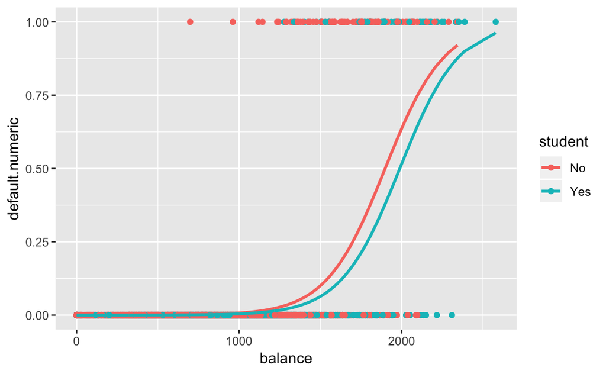

# Exercise 3: Random Forest

In this exercise we will build a random forest model based on the data used to create the visualization [here](http://www.r2d3.us/visual-intro-to-machine-learning-part-1/).

`r`r # Skip first 2 lines since they were comments url <- paste0(://raw.githubusercontent.com/jadeyee/r2d3-part-1-data/, /part_1_data.csv) houses <- read.csv(url, skip = 2) houses <- tbl_df(houses) houses <- houses %>% mutate(city = factor(in_sf, levels = c(1, 0), labels = c(, ))) houses

```
# A tibble: 492 x 9
   in_sf  beds  bath   price year_built  sqft price_per_sqft elevation city
   <int> <dbl> <dbl>   <int>      <int> <int>          <int>     <int> <fct>
 1     0     2     1  999000       1960  1000            999        10 NYC
 2     0     2     2 2750000       2006  1418           1939         0 NYC
 3     0     2     2 1350000       1900  2150            628         9 NYC
 4     0     1     1  629000       1903   500           1258         9 NYC
 5     0     0     1  439000       1930   500            878        10 NYC
 6     0     0     1  439000       1930   500            878        10 NYC
 7     0     1     1  475000       1920   500            950        10 NYC
 8     0     1     1  975000       1930   900           1083        10 NYC
 9     0     1     1  975000       1930   900           1083        12 NYC
10     0     2     1 1895000       1921  1000           1895        12 NYC
# ... with 482 more rows
```

2. Split the data into (70%-30%) train and test set. How many observations are in your train and test sets?

`r`r set.seed(123) train.idx <- sample(nrow(houses), 0.7 * nrow(houses)) train <- houses[train.idx, ] test <- houses[-train.idx, ] dim(train)

```
[1] 344   9
```

`r`r dim(test)

```
[1] 148   9
```

3. Train a random forest on the train set, using all the variables in the model, to classify houses into the ones from San Francisco and from New York. Remember to remove ‘in_sf’, as it is the same variable as ‘city’.

`r`r library(randomForest)

`r`r houses.rf <- randomForest(city ~ . -in_sf, data = train, importance = TRUE, proximity = TRUE) houses.rf

```
Call:
 randomForest(formula = city ~ . - in_sf, data = train, importance = TRUE,      proximity = TRUE)
               Type of random forest: classification
                     Number of trees: 500
No. of variables tried at each split: 2

        OOB estimate of  error rate: 7.56%
Confusion matrix:
     SF NYC class.error
SF  161  17  0.09550562
NYC   9 157  0.05421687
```

4. Compute predictions and print out [the confusion (error) matrix](https://en.wikipedia.org/wiki/Confusion_matrix) for the test set to asses the model accuracy. Also, compute the model accuracy.

`r`r pred <- predict(houses.rf, newdata = test) (confusion.mat <- table(pred, truth = test$city))

```
     truth
pred  SF NYC
  SF  77   9
  NYC 13  49
```

`r`r (accuracy <- sum(diag(confusion.mat))/nrow(test))

```
[1] 0.8513514
```

5. Which features were the most predictive for classifying houses into SF vs NYC groups? Use importance measures to answer the question.

`r`r varImpPlot(houses.rf)

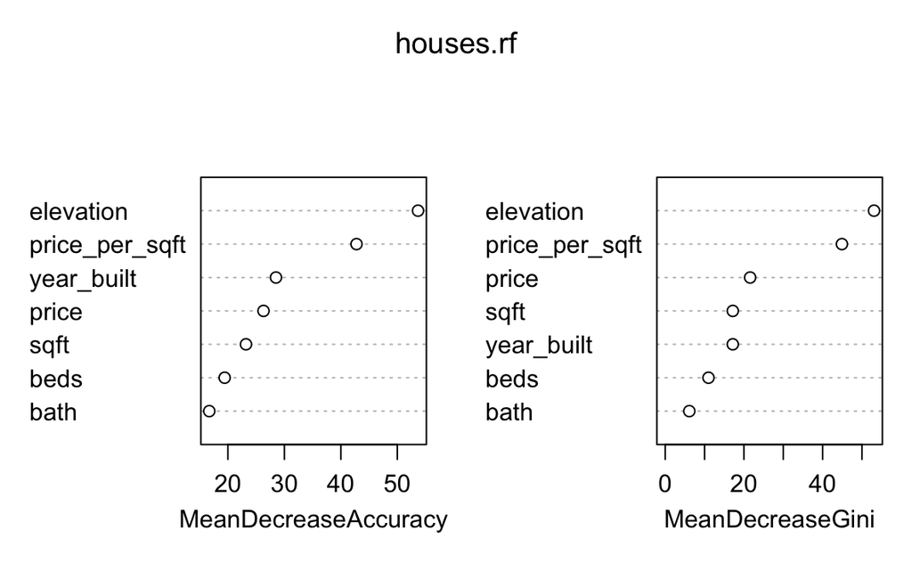